# Resort Booking Analytics

Forecasting stay revenue and targeting likely return guests

Yoneke Graham

November 2026

# Executive summary

- **Revenue forecast:** a linear regression predicts total stay spend from booking-time details with a typical miss of **$102**, half the error of using the average ($207). Nights and party size drive most of the difference.
- **Return targeting:** a logistic regression ranks guests by their chance of returning. Contacting the top 20% reaches guests who return at **55%**, versus 36% overall: **1.5 times** better than random.
- **Loyalty matters:** for a typical booking, gold members are predicted to return **59%** of the time, versus 34% for guests with no tier.
- **Room to grow:** the hit rate holds at about 55% up to 30% contact, so a larger list would reach more returners at no loss in quality.
- **Next step:** the model shows who is likely to return, not whether outreach changes that. A randomized contact test would show whether follow-ups pay for themselves.

# The problem

A resort receives a new booking. Two teams want to use it, but they ask different questions:

- **Revenue** wants to know what the stay will be worth in dollars.
- **Guest relations** can follow up with only 20% of guests after their stay and wants to know whom to contact.

Both teams have the same booking-time information. This project builds a separate model for each question and shows why each one needs its own metric.

**Data.** 1,400 simulated bookings (fictional course data, not real guests). Each row is one booking. Nine fields are known at booking time; two outcomes, total stay spend and whether the guest returned within a year, are recorded later.

```r
raw <- read_csv("data/resort_bookings.csv", show_col_types = FALSE) |> clean_names()

set_factors <- function(df) {
  df |> mutate(
    booking_channel = factor(booking_channel, levels = c("direct", "online_agency", "travel_agent")),
    loyalty_tier    = factor(loyalty_tier,    levels = c("none", "silver", "gold")),
    trip_type       = factor(trip_type,       levels = c("leisure", "business", "conference"))
  )
}

predictors <- ~ nights + quoted_room_rate_usd + party_size + weekend_arrival +
  booking_lead_days + prior_stays + booking_channel + loyalty_tier + trip_type
```

# The data at a glance

```r
eda <- raw |> set_factors()
tier_rates <- eda |> group_by(loyalty_tier) |> summarize(rate = mean(returned_within_year))
```

The data has 1400 bookings and no missing values. Spend averages $1,100 and ranges from $326 to $1,964. About 36% of guests returned within a year.

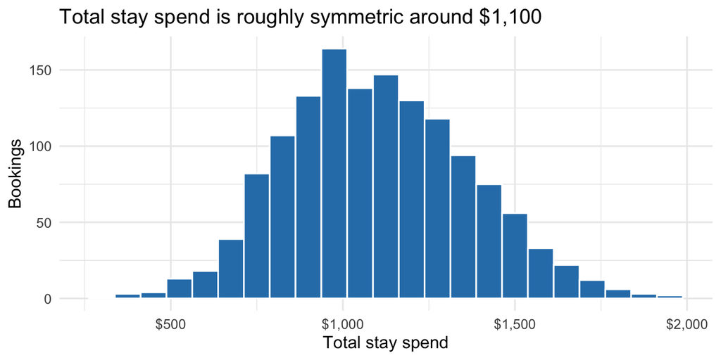

```r
ggplot(eda, aes(total_stay_spend_usd)) +
  geom_histogram(binwidth = 75, fill = "#2c7fb8", colour = "white") +
  scale_x_continuous(labels = scales::dollar) +
  labs(title = "Total stay spend is roughly symmetric around $1,100",
       x = "Total stay spend", y = "Bookings")
```

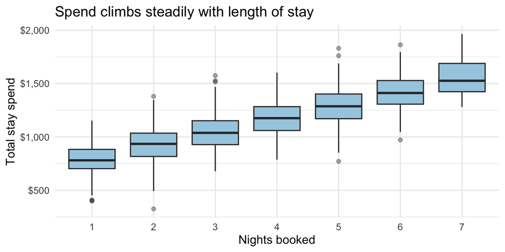

```r
ggplot(eda, aes(factor(nights), total_stay_spend_usd)) +
  geom_boxplot(fill = "#a6cee3", outlier.alpha = 0.4) +
  scale_y_continuous(labels = scales::dollar) +
  labs(title = "Spend climbs steadily with length of stay",
       x = "Nights booked", y = "Total stay spend")
```

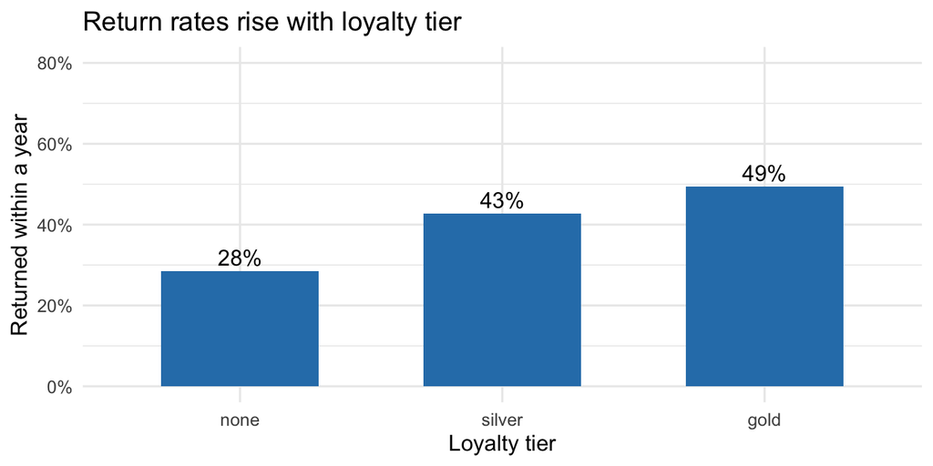

```r
ggplot(tier_rates, aes(loyalty_tier, rate)) +
  geom_col(fill = "#2c7fb8", width = 0.6) +
  geom_text(aes(label = scales::percent(rate, 1)), vjust = -0.4) +
  scale_y_continuous(labels = scales::percent, limits = c(0, 0.8)) +
  labs(title = "Return rates rise with loyalty tier",
       x = "Loyalty tier", y = "Returned within a year")
```

Two patterns stand out before any modeling. Spend rises with the number of nights, which suggests a roughly linear relationship. Return rates differ sharply by loyalty tier, from 28% with no tier to 49% for gold. The models below test whether these patterns hold once the other booking details are taken into account.

# Avoiding leakage

A model is only useful if it can run when a booking arrives. Each model therefore drops the *other* outcome, because neither is known at booking time. Using it would make the model look better than it could ever perform in practice.

| Model | Outcome | Excluded |
| --- | --- | --- |
| Revenue | `total_stay_spend_usd` | `booking_id`, `returned_within_year` |
| Guest relations | `returned_within_year` | `booking_id`, `total_stay_spend_usd` |

Both models use a reproducible 80/20 split (`set.seed(732)`). The test set is used only once, for the final evaluation.

# Part 1: Forecasting stay revenue

Spend is a continuous dollar amount, so I used **multiple linear regression**, compared with a baseline that predicts the training average for every booking.

```r
spend <- raw |> select(-booking_id, -returned_within_year) |> set_factors()

set.seed(732)
a_rows  <- createDataPartition(spend$total_stay_spend_usd, p = 0.80, list = FALSE)
a_train <- spend[a_rows, ]
a_test  <- spend[-a_rows, ]

spend_model <- lm(update(predictors, total_stay_spend_usd ~ .), data = a_train)
mean_spend  <- mean(a_train$total_stay_spend_usd)
```

## What drives spend

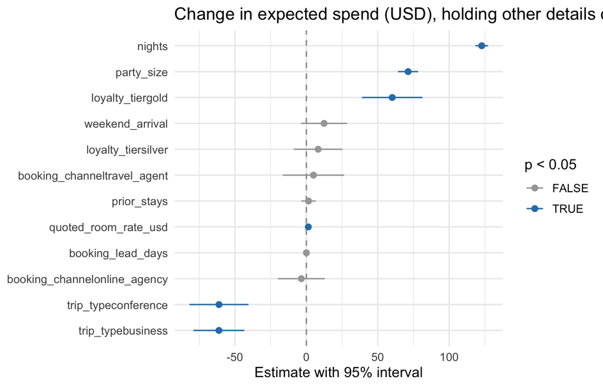

```r
broom_like <- summary(spend_model)$coefficients |>
  as.data.frame() |>
  rownames_to_column("term") |>
  filter(term != "(Intercept)") |>
  transmute(term, estimate = Estimate,
            low = Estimate - 1.96 * `Std. Error`, high = Estimate + 1.96 * `Std. Error`,
            significant = `Pr(>|t|)` < 0.05)

p_coef <- ggplot(broom_like, aes(estimate, reorder(term, estimate), colour = significant)) +
  geom_vline(xintercept = 0, linetype = "dashed", colour = "grey60") +
  geom_errorbarh(aes(xmin = low, xmax = high), height = 0) +
  geom_point(size = 2) +
  scale_colour_manual(values = c(`TRUE` = "#2c7fb8", `FALSE` = "grey65")) +
  labs(title = "Change in expected spend (USD), holding other details constant",
       x = "Estimate with 95% interval", y = NULL, colour = "p < 0.05")
p_coef
```

```r
ggsave("figures/spend_drivers.png", p_coef, width = 7, height = 4.5, dpi = 150, bg = "white")
```

Holding the other booking details constant:

- **Each extra night** adds about **$123** in expected spend, the strongest relationship.
- **Each extra guest** adds about **$71**.
- **Gold members** spend about **$60 more** than guests without a tier.
- **Business and conference trips** spend about **$61 less** than leisure trips.
- Booking channel, lead time, prior stays, and weekend arrival show no clear relationship once these are known.

Diagnostics were clean: residuals show no curve or funnel, they are approximately normal, VIFs are near 1, and no booking has outsized influence (max Cook’s distance ≈ 0.01).

## How accurate is it?

```r
a_pred <- predict(spend_model, newdata = a_test)
a_act  <- a_test$total_stay_spend_usd

a_results <- tibble(
  Model = c("Average (baseline)", "Linear regression"),
  MAE   = c(MAE(rep(mean_spend, nrow(a_test)), a_act), MAE(a_pred, a_act)),
  RMSE  = c(RMSE(rep(mean_spend, nrow(a_test)), a_act), RMSE(a_pred, a_act))
)
kable(a_results, digits = 0, caption = "Test-set dollar error (n = 280 bookings)")
```

Test-set dollar error (n = 280 bookings)

| Model | MAE | RMSE |
| --- | --- | --- |
| Average (baseline) | 207 | 255 |
| Linear regression | 102 | 127 |

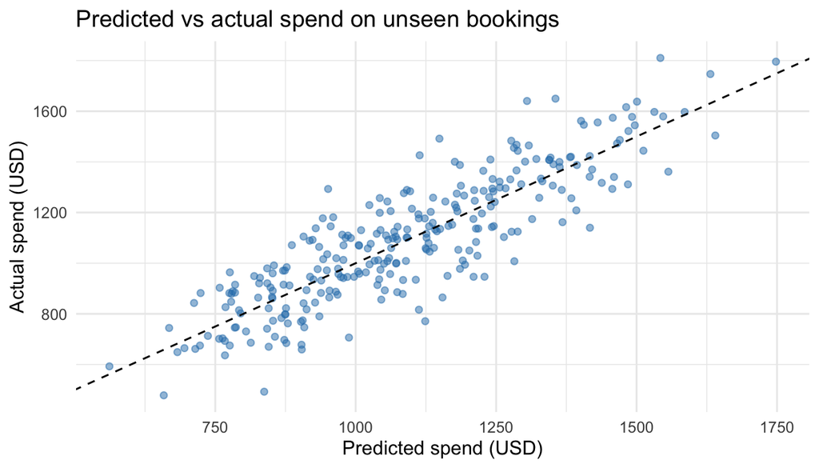

```r
ggplot(tibble(actual = a_act, predicted = a_pred), aes(predicted, actual)) +
  geom_point(alpha = 0.5, colour = "#2c7fb8") +
  geom_abline(linetype = "dashed") +
  labs(title = "Predicted vs actual spend on unseen bookings",
       x = "Predicted spend (USD)", y = "Actual spend (USD)")
```

On bookings the model never saw, the typical miss is about **$102**, half the baseline’s $207, and the model explains about 75% of the variation in spend. For a typical $1,100 stay, the estimate usually lands within about $100, though some stays miss by $400.

**Use it for:** revenue forecasts and planning when bookings arrive, and spotting likely high-value stays. Totals across many bookings are more reliable than any single estimate. **Don’t infer:** that the coefficients are causes. Encouraging an extra night will not necessarily add $123.

# Part 2: Targeting likely return guests

Returning is a yes/no outcome, so I used **logistic regression**, which gives each guest a probability that can be ranked.

```r
ret <- raw |>
  select(-booking_id, -total_stay_spend_usd) |>
  mutate(returned = factor(returned_within_year, levels = c(0, 1), labels = c("no", "yes"))) |>
  select(-returned_within_year) |>
  set_factors()

set.seed(732)
b_rows  <- createDataPartition(ret$returned, p = 0.80, list = FALSE)
b_train <- ret[b_rows, ]
b_test  <- ret[-b_rows, ]

return_model <- glm(update(predictors, returned ~ .), data = b_train, family = binomial())
```

## Who is likely to return

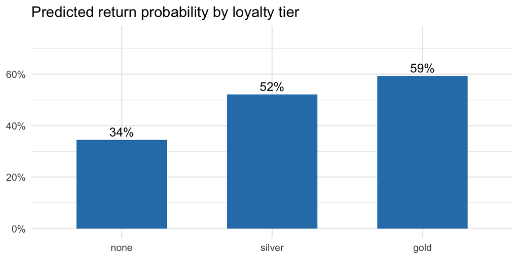

```r
typical <- tibble(
  nights = 3, quoted_room_rate_usd = 230, party_size = 2, weekend_arrival = 0,
  booking_lead_days = 26, prior_stays = 2,
  booking_channel = "direct", loyalty_tier = "none", trip_type = "leisure"
) |> set_factors()

by_tier <- typical[rep(1, 3), ] |>
  mutate(loyalty_tier = factor(c("none", "silver", "gold"), levels = levels(ret$loyalty_tier)))
by_tier$p <- predict(return_model, newdata = by_tier, type = "response")

by_stays <- typical[rep(1, 7), ] |> mutate(prior_stays = 0:6)
by_stays$p <- predict(return_model, newdata = by_stays, type = "response")

p_tier <- ggplot(by_tier, aes(loyalty_tier, p)) +
  geom_col(fill = "#2c7fb8", width = 0.6) +
  geom_text(aes(label = scales::percent(p, 1)), vjust = -0.4) +
  scale_y_continuous(labels = scales::percent, limits = c(0, 0.75)) +
  labs(title = "Predicted return probability by loyalty tier", x = NULL, y = NULL)
p_tier
```

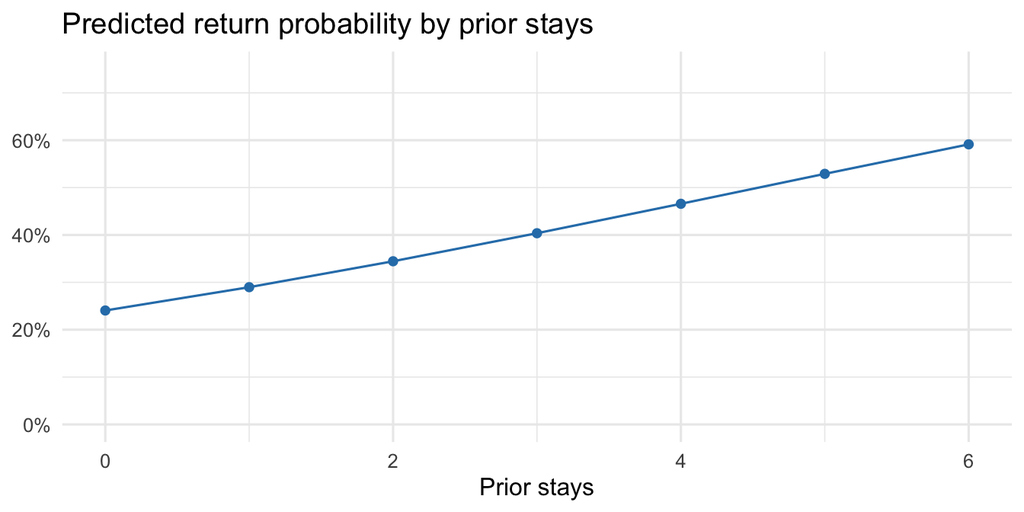

```r
ggsave("figures/return_by_tier.png", p_tier, width = 6, height = 3.5, dpi = 150, bg = "white")

ggplot(by_stays, aes(prior_stays, p)) +
  geom_line(colour = "#2c7fb8") + geom_point(colour = "#2c7fb8") +
  scale_y_continuous(labels = scales::percent, limits = c(0, 0.75)) +
  labs(title = "Predicted return probability by prior stays", x = "Prior stays", y = NULL)
```

## How well does it rank guests?

```r
b_prob <- predict(return_model, newdata = b_test, type = "response")
b_act  <- as.numeric(b_test$returned == "yes")
b_auc  <- as.numeric(auc(roc(b_test$returned, b_prob, levels = c("no", "yes"),
                             direction = "<", quiet = TRUE)))
base_rate <- mean(b_train$returned == "yes")

kable(tibble(
  Measure = c("AUC", "Log loss: model", "Log loss: average rate only"),
  Value   = c(b_auc,
              -mean(b_act * log(b_prob) + (1 - b_act) * log(1 - b_prob)),
              -mean(b_act * log(base_rate) + (1 - b_act) * log(1 - base_rate)))
), digits = 3, caption = "Probability quality on the test set (n = 279 guests)")
```

Probability quality on the test set (n = 279 guests)

| Measure | Value |
| --- | --- |
| AUC | 0.695 |
| Log loss: model | 0.600 |
| Log loss: average rate only | 0.655 |

The model ranks a returner above a non-returner about 70% of the time (AUC ≈ 0.70): useful, but far from certain.

## Choosing whom to contact

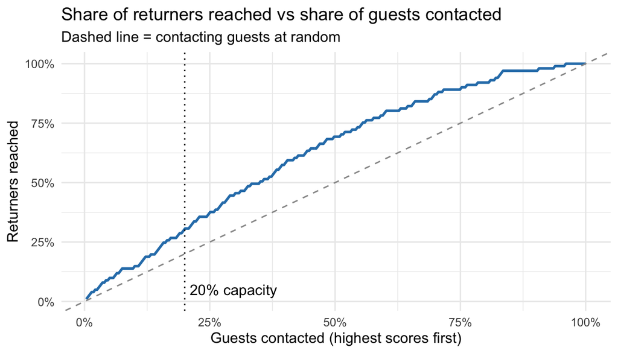

```r
gains <- tibble(prob = b_prob, actual = b_act) |>
  arrange(desc(prob)) |>
  mutate(share_contacted   = row_number() / n(),
         returners_reached = cumsum(actual) / sum(actual),
         precision         = cumsum(actual) / row_number())

p_gains <- ggplot(gains, aes(share_contacted, returners_reached)) +
  geom_line(colour = "#2c7fb8", linewidth = 1) +
  geom_abline(linetype = "dashed", colour = "grey60") +
  geom_vline(xintercept = 0.2, linetype = "dotted") +
  annotate("text", x = 0.21, y = 0.05, label = "20% capacity", hjust = 0) +
  scale_x_continuous(labels = scales::percent) +
  scale_y_continuous(labels = scales::percent) +
  labs(title = "Share of returners reached vs share of guests contacted",
       subtitle = "Dashed line = contacting guests at random",
       x = "Guests contacted (highest scores first)", y = "Returners reached")
p_gains
```

```r
ggsave("figures/gains_curve.png", p_gains, width = 7, height = 4, dpi = 150, bg = "white")

k <- round(c(0.10, 0.20, 0.30) * nrow(gains))
gains[k, ] |>
  transmute(`Contact share` = scales::percent(share_contacted, 1),
            `Of contacted, % returned` = scales::percent(precision, 1),
            `Of all returners, % reached` = scales::percent(returners_reached, 1)) |>
  kable(caption = "Results at different contact capacities")
```

Results at different contact capacities

| Contact share | Of contacted, % returned | Of all returners, % reached |
| --- | --- | --- |
| 10% | 54% | 15% |
| 20% | 55% | 31% |
| 30% | 55% | 46% |

**Recommendation:** rank guests by predicted probability and contact the top 20%. On the test set, 55% of contacted guests returned, compared with 36% overall, so the list is about **1.5 times better** than contacting guests at random. A fixed 0.50 cutoff happened to select a similar number of guests here, but it ignores capacity; ranking always matches what the team can handle.

**Tradeoffs:** nearly half of contacted guests will not return, so follow-ups should be low-cost. Most returners will not be contacted, mainly because of the 20% limit.

**If capacity could grow:** the share of contacted guests who return stays at about 55% from 10% up to 30% contact. Expanding outreach to 30% would reach 46% of returners instead of 31%, with no loss in hit rate. If the cost of a contact is low compared with the value of a return visit, a larger list is worth testing.

**What this does not show:** the model identifies who is *likely* to return, not whether contacting them *causes* a return. High scorers, such as gold members, may return anyway. To measure the effect of outreach, randomly contact half of the top-scoring guests, leave the other half alone, and compare their return rates.

## Does outreach pay for itself?

A contact only creates value if it **changes** whether a guest returns. Guests on the list who would have returned anyway add no new revenue. The useful question is therefore: how much would a contact need to raise a guest’s chance of returning to cover its cost?

If a return visit is worth about one average stay ($1,102), the break-even lift is the contact cost divided by that value.

```r
tibble(`Cost per contact` = c(5, 10, 25, 50)) |>
  mutate(`Break-even lift in return chance` =
           scales::percent(`Cost per contact` / mean_spend, 0.1),
         `Contacts per extra return needed` =
           floor(mean_spend / `Cost per contact`),
         `Cost per contact` = scales::dollar(`Cost per contact`)) |>
  kable(caption = "Break-even lift for outreach, valuing a return visit at one average stay")
```

Break-even lift for outreach, valuing a return visit at one average stay

| Cost per contact | Break-even lift in return chance | Contacts per extra return needed |
| --- | --- | --- |
| $5 | 0.5% | 220 |
| $10 | 0.9% | 110 |
| $25 | 2.3% | 44 |
| $50 | 4.5% | 22 |

The bar is low. A $10 email or call pays off if it raises a guest’s chance of returning by about 1 percentage point. In other words, roughly one extra return per 110 contacts covers the cost. Whether outreach clears that bar is unknown, and it is exactly what a randomized contact test would measure. Because many top-scoring guests already return at 55%, the test should also check whether outreach works better for guests in the middle of the ranking, who have more room to be persuaded.

# Takeaway

The same booking data answers two different questions, and each needs its own measure of success:

| Team | Answer | Judged by |
| --- | --- | --- |
| Revenue | A dollar estimate per booking | Dollar error (MAE ≈ $102) |
| Guest relations | A ranked contact list at 20% capacity | Ranking (AUC ≈ 0.70) and share of contacts who return (55%) |

*Tools: R (tidyverse, caret, pROC). Data: simulated resort bookings from a graduate analytics course; not real guests or resort performance.*